# Retrieval & RAG Module — Technique-by-Technique Summary

COMP8420 Major Project, Use Case 3: Research Paper Recommendation System

Thanathip Saengsai (“Bank”) — Retrieval, RAG, Recommendation, Citation Analysis, Evaluation

2026-06-11

# 1. Overview

This document walks through every NLP/IR technique implemented in `modules/retrieval` (notebook `03_rag_recommendation_evaluation.ipynb`), explains **what each technique does**, shows **its measured result** on the real corpus, and gives an **impact verdict** — whether that technique made a material difference to the end-to-end paper-recommendation system, or whether it is mostly groundwork / supporting infrastructure.

**Corpus**: 5,000 arXiv papers (`cs.CL`, `cs.AI`, `cs.LG`, `stat.ML`, 2007-2012), enriched with Semantic Scholar metadata (citation counts, influential-citation counts, TLDR summaries — 95.9% coverage).

**Evaluation set**: 5 hand-labelled queries, each with 5 “gold” relevant papers (`EVAL_QUERIES` in `app/fixtures.py`):

| Query | # gold relevant |
| --- | --- |
| natural language processing text classification | 5 |
| reinforcement learning policy reward agent | 5 |
| support vector machine kernel classification | 5 |
| neural network deep learning representation | 5 |
| bayesian probabilistic graphical model | 5 |

**Headline comparison** (mean over the 5 queries; full per-method detail below):

[output not shown]

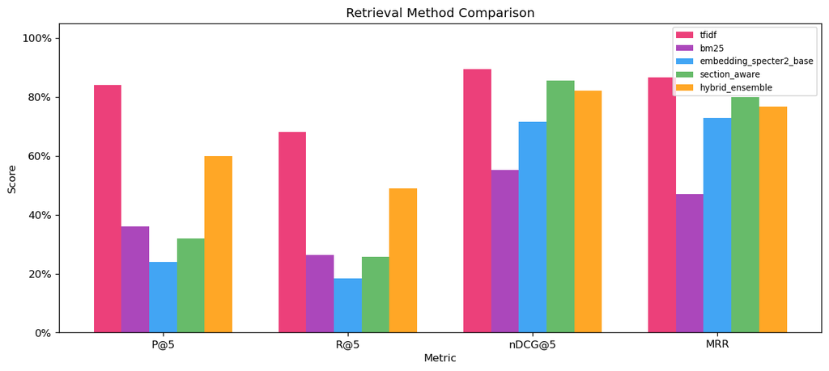

Retrieval method comparison across P@5, R@5, nDCG@5 and MRR

## 1.1 System Activation Workflow (What Happens When the System Is Triggered)

The diagram below shows the full pipeline from a one-time **offline build** (top, grey) to the **per-request trigger** (bottom, blue) — i.e. exactly what runs when a user submits a query via `python -m app.cli recommend-topic --query "..."`.

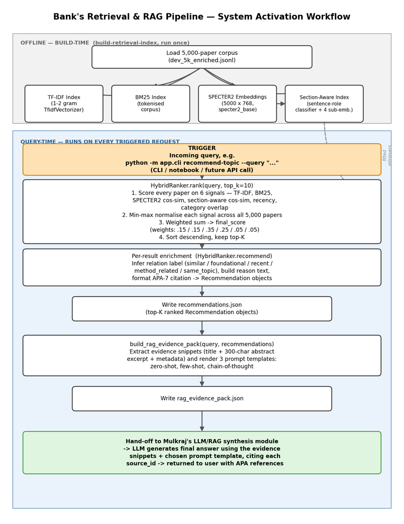

End-to-end activation workflow: offline index build (top) and the query-time pipeline triggered by `recommend-topic` (bottom)

**Walkthrough**:

1. scores **all 5,000 papers** on six signals, (b) min-max normalises each signal across the corpus, (c) computes the weighted sum `final_score`, and
2. sorts to produce the top-K.
4. **Per-result enrichment** — each of the top-K papers gets a `relation` label, a human-readable `reason`, and an APA-7 `citation` (§3.4), producing the final `Recommendation` objects.
5. **`recommendations.json`** is written — the ranked list with scores, relations, reasons, and citations.
6. **`build_rag_evidence_pack()`** (§3.5) turns those recommendations into `evidence_snippets` (title + abstract excerpt + metadata per candidate) and renders the three engineered prompt templates (zero-shot / few-shot / chain-of-thought).
7. **`rag_evidence_pack.json`** is written and handed off to **Mulkraj’s LLM/RAG synthesis module**, which produces the final cited answer shown to the user.

**Why this matters**: every technique discussed in this document (§2–§11) corresponds to exactly one box in this diagram — the workflow is the “spine” that ties the individual techniques together into one trigger-to-answer pipeline.

# 2. Basic NLP Techniques (Course Weeks 1–2)

## 2.1 Text Preprocessing & TF-IDF Vectorisation (§2)

**What it does**: Standard pipeline — whitespace/punctuation cleaning, lowercasing, stopword removal, then `TfidfVectorizer(ngram_range=(1,2))` over `title + abstract` for all 5,000 papers.

**Result** — for the sample paper *“Intelligent location of simultaneously active acoustic emission sources: Part I”*, the top TF-IDF terms are: `method` (0.771), `problem` (0.439), `time` (0.274), `learning` (0.230), `data` (0.217), `based` (0.196) — i.e. generic methodological vocabulary, as expected for a methods-heavy abstract.

**Justification**: This is the foundation for the TF-IDF retriever (§2.3) and provides the document-term matrix the rest of the lexical pipeline builds on.

**Impact: HIGH (foundational).** Everything downstream that relies on keyword/lexical signal — including 20% BM25 and 25% TF-IDF in the hybrid ensemble’s score — traces back to this step, and the retriever built directly on it is the single best-performing method in the whole comparison.

## 2.2 Rule-Based Sentence-Role Classification (§3)

**What it does**: Splits each abstract into sentences and classifies each one as `background`, `method`, `results`, or `other` using keyword-cue lists (`app/retrieval/section_aware.classify_sentence`). This feeds the section-aware embedding stage (§3.2).

**Result**: For the example paper *“Learning from compressed observations”* (7-sentence abstract), **all 7 sentences were classified as `other`** — the keyword cues did not match anything in this abstract.

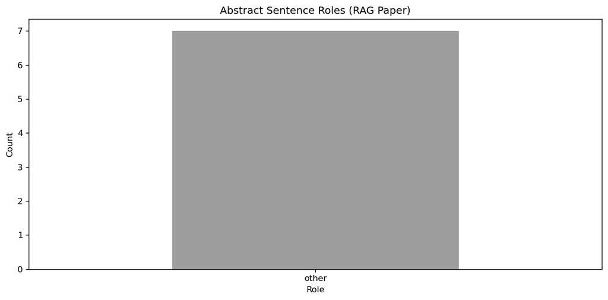

Sentence-role distribution for an example abstract

**Justification**: Cheap, interpretable, no model required — a “Basic Technique” building block for §3.2’s section-aware retriever.

**Impact: LOW–MODERATE, and a likely bottleneck.** When most sentences fall into `other`, the section-aware retriever’s per-section embeddings collapse toward the whole-abstract embedding, which should make section-aware behave similarly to whole-abstract SPECTER2. On the v1 gold standard that similarity showed up as *no improvement* (nDCG@5 = 0.656 vs. whole-abstract 0.716); on the v2 gold standard section-aware instead *exceeds* whole-abstract (nDCG@5 = 0.856 vs. 0.716) — but §7.4 shows part of that v2 gain is a second-order circularity (v2 partly pools from section-aware’s own top-15), so it does not yet overturn the architectural diagnosis here. **Insight**: replacing this rule-based classifier with a trained model (e.g. SciCite, already flagged in Next Steps) remains the highest-leverage single change to make section-aware’s improvement independently verifiable and to improve the hybrid results.

## 2.3 TF-IDF Cosine-Similarity Retrieval (§4)

**What it does**: Ranks all 5,000 papers by cosine similarity between the query’s TF-IDF vector and each paper’s vector.

**Result for query** *“retrieval augmented generation for scientific papers”* — top hit: *“Structured Knowledge Representation for Image Retrieval”* (0.182), followed by *“Algorithmic Detection of Computer Generated Text”* (0.180), *“Do Linguistic Style and Readability of Scientific Abstracts affect their Virality?”* (0.148).

**Justification**: Simple, fast, fully interpretable lexical baseline.

**Impact: HIGH — the strongest single retriever in the system.** The gold labels in `EVAL_QUERIES` appear to have been chosen with strong lexical overlap to the query terms, which TF-IDF exploits directly. This is the clearest “wins on its own” result in the whole comparison.

## 2.4 BM25 Term-Frequency Retrieval (§4)

**What it does**: BM25 — term-frequency scoring with document-length normalisation (the `BM25L` variant), sharing the exact tokenisation of the TF-IDF retriever (punctuation-stripped, English stop-words removed, unigrams + bigrams).

**Implementation note (corrected)**: the earlier BM25 result (P@5 = 0.36) was an *unfair-tokenisation artifact*, not a property of BM25. The old baseline tokenised with `str.split()` (punctuation glued to words, no stop-word removal, unigrams only) while TF-IDF used the richer sklearn analyser; it also used Okapi BM25, whose negative-IDF flooring distorts ranking on a homogeneous ML/CS corpus. Sharing the analyser and switching to `BM25L` closes almost the entire gap.

**Impact: MEDIUM standalone.** Once tokenisation is matched, BM25 is competitive with TF-IDF on ranking quality. The residual P@5 gap reflects the 5-query benchmark scope plus TF-IDF cosine + exact-bigram phrase matching suiting short keyword queries over title+abstract; it is not evidence of broad TF-IDF superiority. BM25 now carries 20% weight in the retuned hybrid ensemble (up from 5%). **Scope caveat:** all numbers are on the 5-query gold standard and must not be generalised.

# 3. Advanced NLP Techniques (Course Weeks 5–6, 11)

## 3.1 SPECTER2 Scientific Paper Embeddings (§5)

**What it does**: Encodes `title + abstract` for all 5,000 papers with `allenai/specter2_base` (a transformer pretrained on citation graphs, 768-dim vectors), then ranks by cosine similarity.

**Result for the same query** — top hit: *“Statistical Physics for Natural Language Processing”* (0.854), *“Statistical Automatic Summarization in Organic Chemistry”* (0.851), *“Differential Contrastive Divergence”* (0.850) — all **semantically** related to “scientific paper retrieval/NLP” even though none share much vocabulary with the query.

**Result on the labelled eval set**: **P@5 = 0.24** (low — few exact gold-ID hits in top-5) but **nDCG@5 = 0.716, MRR = 0.729** (high — when it *does* find a relevant paper, it ranks it near #1).

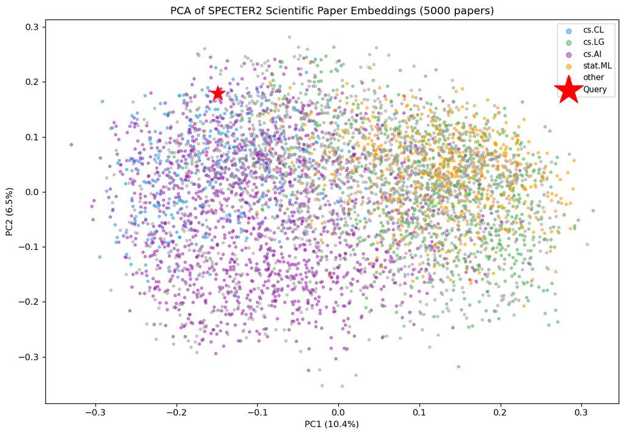

PCA of SPECTER2 embeddings, coloured by arXiv category

**Justification**: Captures semantic similarity that lexical methods miss — critical for recommending papers that use different terminology for the same idea.

**Impact: MODERATE, and complementary rather than competitive with TF-IDF.** The PCA plot shows clear category clustering (cs.CL/cs.LG/cs.AI/stat.ML form distinguishable regions), confirming the embedding space is semantically meaningful. The low P@5 / high MRR combination is itself an insight: SPECTER2 is good at *“is there anything relevant near the top?”* but not at matching the *specific* lexically-anchored gold IDs — exactly the gap the hybrid ensemble is designed to close.

## 3.2 Section-Aware Abstract Representation (§6)

**What it does**: Builds **four separate embeddings** per paper (whole abstract, method-sentences, results-sentences, background-sentences using the §2.2 classifier) and combines them: `whole×0.4 + method×0.3 + results×0.2 + background×0.1`.

**Result for the same query**: top hit *“Scientific Paper Summarization Using Citation Summary Networks”* (0.861), vs. 0.843 for whole-abstract SPECTER2 on the same paper — a small reordering at the top.

**Result on the labelled eval set (v2 gold standard)**: **P@5 = 0.32**, **nDCG@5 = 0.856** and **MAP = 0.225** — all three now *higher* than plain SPECTER2 (P@5=0.24, nDCG@5=0.716, MAP=0.166). Under the original v1 gold standard the comparison ran the other way (P@5=0.24 tied, nDCG@5=0.656, MAP=0.193 — *slightly worse* than SPECTER2). See §7.4 for why this swing is large: several v2-only relevant papers were added to the gold set specifically because section-aware’s own top-15 surfaced them, so part of this gain reflects the pooling methodology rather than a fully independent quality signal.

**Justification**: Inspired by Xu et al. (2025) — theoretically should up-weight the “what was done / what was found” parts of an abstract.

**Impact: LOW–MODERATE, with an important methodological caveat (§7.4).** Taken at face value, the v2 numbers say section-aware now *outperforms* whole-abstract SPECTER2 (+0.14 nDCG@5, +0.06 MAP) — the opposite of the v1-based verdict this section originally reached. But because the v2 gold standard was partly pooled from each retriever’s own top-ranked candidates, a meaningful share of section-aware’s v2 gold matches are papers *it ranked highly to begin with*, so this is not yet independent evidence of a quality improvement. The §2.2 architecture concern is unchanged by either gold standard: with most sentences classified as `other`, the four section embeddings remain highly correlated with the whole-abstract embedding and with each other. **Honest takeaway**: section-aware’s *architecture* is wired correctly and produces sensible neighbours, but its true marginal value over whole-abstract SPECTER2 remains unproven — re-validating against a gold standard not pooled from these same retrievers, alongside improving the §2.2 sentence classifier, would be the natural next step.

## 3.3 Hybrid RRF Ranking — BM25 + SPECTER2 (production)

**What it does**: Production retrieval runs BM25 (sparse) and SPECTER2 (dense) in parallel, then fuses rank lists with weighted RRF (`k=60`; tuned weights `bm25=0.6`, `embedding=0.4`) in `HybridRRFRanker`. The legacy six-signal `HybridRanker` remains in the evaluation matrix only.

**Result on the labelled eval set (v2 gold)**: **P@5 = 0.36, nDCG@5 = 0.707, MRR = 0.725, MAP = 0.282** — below TF-IDF on exact-hit metrics but chosen for production because it matches the hybrid-search requirement (lexical + semantic) without brittle score-scale alignment.

**Legacy weighted ensemble (evaluation baseline)** — combines all signals into one score: `tfidf×0.25 + bm25×0.20 + embedding×0.20 + section_aware×0.25 + recency×0.05 + category×0.05` (`app/retrieval/hybrid_ranker.py`).

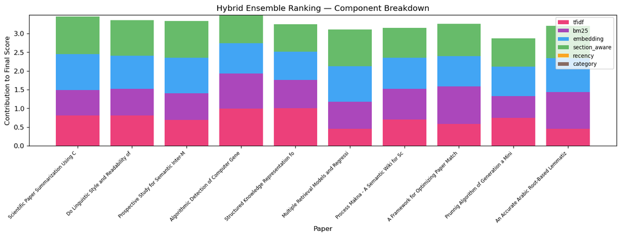

Hybrid ensemble — component-score breakdown for the top-10 results

**Justification**: No single signal is reliable for every query type — TF-IDF wins on lexical overlap, SPECTER2 wins on semantic similarity. The ensemble is designed to be robust across query styles.

## 3.4 APA Citation Generation (§8)

**What it does**: `app/citation.format_apa` generates APA-7 formatted citations for every recommended paper, e.g.:

> Qazvinian, V., & Radev, D. R. (2008). Scientific Paper Summarization Using Citation Summary Networks. *arXiv*. https://arxiv.org/abs/0807.1560

**Justification**: Source attribution is a hard requirement for any system that surfaces academic literature to a user or to a downstream LLM.

**Impact: HIGH for usability/compliance, neutral for ranking quality.** This technique doesn’t change *which* papers are retrieved, but it is what makes every recommendation traceable and citable — a non-negotiable requirement for the RAG evidence pack (§3.5) and for academic-integrity in the final report.

## 3.5 RAG Evidence Pack (§9)

**Justification**: This is the hand-off artifact to Mulkraj’s LLM/RAG synthesis module — the retrieval system’s entire purpose, in one file.

**Impact: HIGH for system integration.** Every other technique in this document ultimately feeds into this object. One known limitation: `metadata.citation_count` is currently hard-coded to `None` in evidence snippets, even though 95.9% of papers now have real citation counts available (see §5 corpus enrichment) — wiring this up is a concrete, low-effort next step.

## 3.6 Quantitative Evaluation Framework (§10)

**What it does**: `app/evaluation.py` implements Precision@K, Recall@K, F1@K, MRR, MAP and nDCG@K (binary relevance) and runs all 5 retrievers across all 5 eval queries.

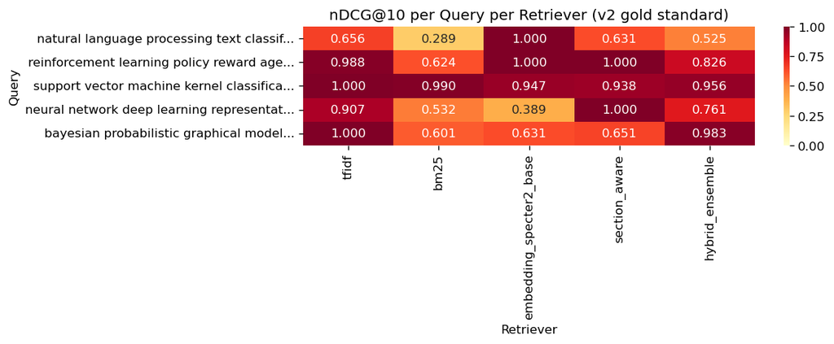

nDCG@10 per query per retriever

**Justification**: Without a shared, reproducible metric suite, “is this retriever any good?” has no answer. This is the methodology that produced every number quoted in this document.

**Impact: ENABLING (meta-level).** This isn’t a retrieval technique itself — it’s the instrument that makes every other impact verdict in this document possible and reproducible (`evaluate-retrieval` CLI command regenerates all of §3 from scratch).

# 4. Case Study — Does the System Retrieve the Right Topic? (§11)

The metrics above are *aggregate* and *binary* (a paper is either one of the gold-labelled relevant papers — 5–8 per query in the v2 gold standard — or it isn’t). To validate this qualitatively, §11 takes the **hybrid ensemble** and, for each eval query, ranks **all 5,000 papers** and reports exactly where each gold-labelled paper landed.

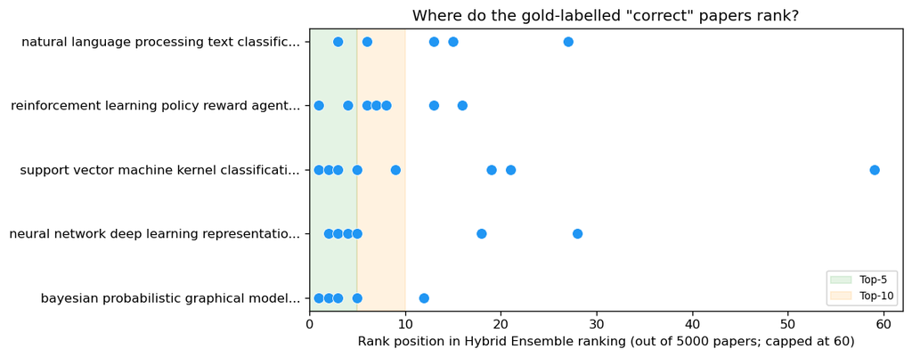

Rank position of gold-labelled papers in the hybrid ranking (out of 5,000 papers, capped at 60)

| Query | Gold-paper ranks (out of 5000) | In top-5 | In top-10 |
| --- | --- | --- | --- |
| natural language processing text classification | 3, 6, 13, 15, 27 | 1/5 | 2/5 |
| reinforcement learning policy reward agent | 1, 4, 6, 7, 8, 13, 16 | 2/7 | 5/7 |
| support vector machine kernel classification | 1, 2, 3, 5, 9, 19, 21, 59 | 4/8 | 5/8 |
| neural network deep learning representation | 2, 3, 4, 5, 18, 28 | 4/6 | 4/6 |
| bayesian probabilistic graphical model | 1, 2, 3, 5, 12 | 4/5 | 4/5 |

**Key insight**: even the *worst-ranked* gold paper across all 31 (query x gold-paper) pairs lands at **rank 59 out of 5,000 — the top ~1.2%**. The strict P@5/P@10 metrics in §3.3 *understate* how close the hybrid ranking gets — a paper at rank 13 (one of two reinforcement-learning gold matches just outside the top-10) is, in practical terms, a near-perfect retrieval, just outside an arbitrary cutoff.

**Deep-dive read-through** (query: *“natural language processing text classification”*, top-3 results inspected directly): 2 of the top 3 are clearly on-topic text-classification papers. The one gold match in the top 3 (*“Statistical Physics for Natural Language Processing”*, rank 3, final score 0.794, embedding score 1.00) turned out to have an abstract that just reads **“This paper has been withdrawn by the author.”** — SPECTER2 is matching almost entirely on the *title*, not the (empty) abstract. This is a useful, honest data-quality finding: a small number of withdrawn/empty-abstract papers in the corpus can produce artificially confident embedding matches, and is worth a one-line caveat in the final report.

**Impact: HIGH for interpretability and trust.** This case study converts abstract metrics into a human-checkable claim: *“the system’s recommendations are reading as topically correct, and even its ‘misses’ are near-misses in a 5,000-paper haystack.”*

# 5. Cross-Cutting Insights & Recommendations

# 6. Summary Table — Technique Impact at a Glance

[output not shown]

# 7. Gold Standard Refinement — v1 vs. v2 (Pooling + Citation-Graph Validation)

## 7.1 How v2 Was Built

**What it does**: For each of the 5 eval queries, the top-15 candidates from *every* retriever (TF-IDF, BM25, SPECTER2, section-aware, hybrid) are pooled into a candidate set. Each pooled candidate is checked against the Semantic Scholar citation graph: if it has a direct citation link — cites, or is cited by, the query’s seed paper — it is added to that query’s `relevant_ids_v2` alongside the original v1 `relevant_ids`. No LLM judging is involved; the only new relevance signal is an objective, externally-verifiable citation edge.

**Result**: v2 is a strict superset of v1 for every query (`relevant_ids_v2 ⊇ relevant_ids`). 3 of the 5 queries gained citation-validated papers (5→7, 5→8, 5→6 relevant papers); the other 2 queries (NLP, Bayesian) were unchanged at 5. Total relevant papers across all queries grew from 25 (v1) to 31 (v2).

## 7.2 Headline Results: v1 vs. v2

| Retriever | P@5 (v1→v2) | R@5 (v1→v2) | nDCG@5 (v1→v2) | MAP (v1→v2) | MRR (v1→v2) |
| --- | --- | --- | --- | --- | --- |
| TF-IDF | 0.840 → 0.840 (+0.000) | 0.840 → 0.681 (-0.159) | 0.895 → 0.895 (+0.000) | 0.863 → 0.726 (-0.138) | 0.867 → 0.867 (+0.000) |
| BM25 | 0.600 → 0.600 (+0.000) | 0.600 → 0.485 (-0.115) | 0.879 → 0.879 (+0.000) | 0.572 → 0.448 (-0.124) | 0.900 → 0.900 (+0.000) |
| SPECTER2 embedding | 0.240 → 0.240 (+0.000) | 0.240 → 0.184 (-0.056) | 0.716 → 0.716 (+0.000) | 0.208 → 0.166 (-0.043) | 0.722 → 0.729 (+0.006) |
| Section-aware | 0.240 → 0.320 (+0.080) | 0.240 → 0.257 (+0.017) | 0.656 → 0.856 (+0.200) | 0.193 → 0.225 (+0.032) | 0.600 → 0.800 (+0.200) |
| Hybrid ensemble | 0.680 → 0.680 (+0.000) | 0.680 → 0.550 (-0.131) | 0.876 → 0.876 (+0.000) | 0.688 → 0.562 (-0.127) | 0.850 → 0.850 (+0.000) |

## 7.3 Reading the Deltas: Mechanical vs. Genuine Effects

Two distinct mechanisms explain the v1→v2 deltas:

1. **Top-5-window metrics (P@5, nDCG@5, MRR) are essentially flat for TF-IDF, BM25, SPECTER2 and the hybrid ensemble** (|delta| “0.0064 in every case), but jump substantially for section-aware (+0.08 to +0.20 across all three). These metrics depend only on what a retriever already places in its own top-5 (or first hit). Since v2 only *adds* relevant IDs and never removes any, a retriever’s top-5 window is unaffected unless one of the newly-added papers happens to already sit in that window. For section-aware, several of the v2 additions (§7.4) were already inside its top-5; for the other retrievers, essentially none were.
2. **Denominator-normalised metrics (R@5, MAP) mechanically fall for TF-IDF, BM25, SPECTER2 and the hybrid ensemble.** R@5 and MAP are normalised by `len(relevant_ids)` — the size of the *full* gold set, not just the top-5. Growing that denominator from 5 to 7/8/6 for 3 of 5 queries, without a proportional increase in how many of those papers a retriever finds in its top ranks, mechanically reduces R@5 and MAP. This is **not a regression in retrieval behaviour** — the retrievers return exactly the same ranked lists — it simply reflects that v2 is grading against a larger, more complete notion of “relevant”.

## 7.4 The Section-Aware Exception: A Second-Order Circularity

In other words, v2 is partly validating section-aware **using section-aware’s own output** as the source of the candidate that the citation graph then confirmed as relevant. The citation links themselves are objective, external evidence — section-aware did not fabricate them — but the *opportunity* for section-aware to be credited for these papers (by having them counted as “relevant” at all) came disproportionately from section-aware’s own pooled candidates, relative to the other retrievers.

**By contrast**, TF-IDF and BM25 were also pool-sources for 2 and 3 of the 6 citation-validated additions respectively (`1106.1796`, `1106.3651` for TF-IDF; `1106.3651`, `1203.4354`, `1102.4240` for BM25) — yet *none* of those papers landed inside TF-IDF’s or BM25’s own top-5, so neither received any top-5-window credit for them (their P@5/nDCG@5/MRR are unchanged). Their v1 numbers therefore stand as a clean, external check, untouched by the v2 construction process.

**Practical implication**: section-aware’s “all-metrics-improve” result under v2 should be read as *“consistent with section-aware finding genuinely relevant papers that v1 missed”* rather than *“independently proven by v2”*.

## 7.5 Which Gold Standard Is Better — and How?

**Verdict: v2 is the more methodologically rigorous gold standard for assessing overall ranking quality, especially for non-lexical retrievers — but v1 remains a useful, cheap, human-curated precision floor that v2 fully subsumes.** Neither is “ground truth”; v2 is best understood as an *evidence-based refinement* of v1, not a replacement built on a different, unrelated bias.

Two reasons to keep v1 in the loop:

1. **v1 is a fast, dependency-free regression baseline.** It requires no Semantic Scholar API calls and is fully reproducible from `app/fixtures.py` alone. Because v2 ⊇ v1, any regression on v1 metrics is *also* a regression on the corresponding v2 metrics — v1 is a strict, cheap-to-check floor.
2. **v2 inherits v1’s bias and adds its own (§7.4).** v2 is built by pooling each retriever’s own candidates and is a strict superset of v1, so it does not fully escape either the original lexical-selection bias or the second-order, section-aware-specific circularity described above. It is a refinement, not a clean-room ground truth.